# MNIST in Keras with R

The MNIST database (Modified National Institute of Standards and Technology database) is a large database of labelled handwritten digits.

The MNIST database is also widely used for training and testing in the field of machine learning, and is considered the ‘Hello World’ task of image processing.

## Keras

We will be using the `Keras` library to construct the model. Keras is much more user-friendly than TensorFlow, and we will be able to push away some of the difficult parts to `Keras` to solve so we make fewer errors. Keras also comes with better defaults, so our models should have fewer simple errors (e.g. forgetting to add biases) overall.

### Load the MNIST Dataset

```r
library(keras)
mnist <- dataset_mnist()
x_train <- mnist$train$x
y_train <- mnist$train$y
x_test <- mnist$test$x
y_test <- mnist$test$y
image_width <- 28
image_size <- image_width ** 2
```

### Visualise the data

Lets have a go at seeing the first few images in the dataset.

[interactive chart not shown]

```r
# reshape data
dim(x_train) <- c(nrow(x_train), image_size)
dim(x_test) <- c(nrow(x_test), image_size)
y_train <- to_categorical(y_train, 10)
y_test <- to_categorical(y_test, 10)
```

```r
bad_model <- keras_model_sequential(name = 'bad_model')
bad_model %>%
  layer_dense(units = 16, activation = 'relu', input_shape = c(image_size)) %>%
  layer_dense(units = 10, activation = 'softmax')
```

```r
summary(bad_model)
```

```
_____________________________________________________________________________________________________________________________
Layer (type)                                            Output Shape                                      Param #
=============================================================================================================================
dense_1 (Dense)                                         (None, 16)                                        12560
_____________________________________________________________________________________________________________________________
dense_2 (Dense)                                         (None, 10)                                        170
=============================================================================================================================
Total params: 12,730
Trainable params: 12,730
Non-trainable params: 0
_____________________________________________________________________________________________________________________________
```

```r
bad_model %>% compile(
  loss = 'categorical_crossentropy',
  optimizer = optimizer_rmsprop(),
  metrics = c('accuracy')
)
```

```r
history <- bad_model %>%
  fit(x_train, y_train,
  epochs = 30, batch_size = 128,
  validation_split = 0.2,
  callbacks = callback_tensorboard(
    log_dir = "logs", write_grads = TRUE, write_images = TRUE)
)
```

### Plot Loss and Accuracy

It’s easy to plot the loss and model accuracy.

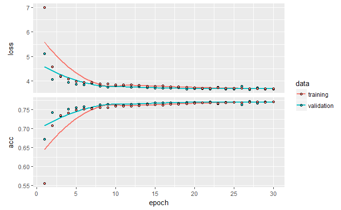

```r
plot(history)
```

It’s also easy to evaluate the model on the test data.

```r
bad_model %>% evaluate(x_test, y_test, verbose = 0)
```

```
$loss
[1] 5.229879

$acc
[1] 0.6732
```

```r
entropy <- function(p) - sum(ifelse(p > 0, p * log(p), 0))
preds <- bad_model %>%
  predict_proba(x_test) %>%
  as_tibble()
colnames(preds) <- 0:9
preds <- tibble(
      class   = apply(preds,  1, which.max) - 1,
      target  = apply(y_test, 1, which.max) - 1,
      entropy = apply(preds,  1, entropy),
      image   = lapply(1:nrow(x_test), function(i) reshape_image(x_test[i, 1:image_size]))) %>%
  mutate(correct = class == target)
preds
```

| class | target | entropy | image | correct |
| --- | --- | --- | --- | --- |
| 7 | 7 | 0.000000e+00 |  | TRUE |
| 2 | 2 | 0.000000e+00 |  | TRUE |
| 1 | 1 | 0.000000e+00 |  | TRUE |
| 5 | 0 | 0.000000e+00 |  | FALSE |
| 9 | 4 | 0.000000e+00 |  | FALSE |
| 1 | 1 | 0.000000e+00 |  | TRUE |
| 9 | 4 | 0.000000e+00 |  | FALSE |
| 9 | 9 | 0.000000e+00 |  | TRUE |
| 5 | 5 | 0.000000e+00 |  | TRUE |
| 9 | 9 | 0.000000e+00 |  | TRUE |

[output cut: 990 more lines]

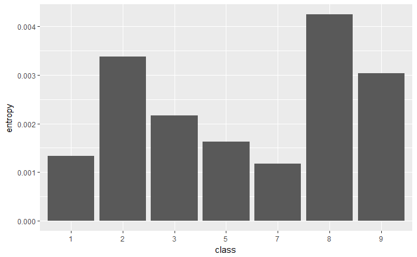

```r
preds %>%
  group_by(class) %>%
  summarise(entropy = mean(entropy)) %>%
  mutate(class = as.character(class)) %>%
  ggplot(aes(x = class, y = entropy)) +
  geom_bar(stat = 'identity')
```

```r
preds %>%
  group_by(class, target) %>%
  summarise(best_image = image[which.min(entropy)], count = n()) %>%
  full_join(tibble(class = Reduce(c, lapply(seq(0, 9), function(x) rep(x, 10))),
      target = rep(seq(0, 9), 10)),
    by = c('class', 'target')) %>%
  mutate(count = ifelse(is.na(count), 0, count)) %>%
  mutate(best_image = ifelse(sapply(best_image, function(x) length(x) == 0),
    list(matrix(as.integer(rep(0, image_size)), nrow = image_width)),
    best_image)) %>%
  mutate(weighted_image = mapply(
    function(c, img) list(c * img), c = count, img = best_image)) %>%
  arrange(desc(class), desc(target)) %>%
  summarise(row = list(Reduce(cbind, weighted_image))) %>%
  do(as_tibble(Reduce(rbind, .$row))) %>%
  as.matrix() %>%
  log() %>%
  plot_image(fig_params = params,
             img_params = list(palette = colorRampPalette(c('dark blue', 'green', 'yellow', 'orange', 'dark red'))(100)))
```

```
Calling 'structure(NULL, *)' is deprecated, as NULL cannot have attributes.
  Consider 'structure(list(), *)' instead.
```

[interactive chart not shown]

Come here for the CNN model: https://keras.rstudio.com/articles/examples/mnist_cnn.html